# Risk Factor Analysis

## Outcome Variable

**Outcome Variable:** ever_stunted

## Predictor Variables

**Intervention Variable:** nrooms

**Adjustment Set:**

unadjusted

## Stratifying Variables

The analysis was stratified on these variable(s):

- agecat
- studyid

The following strata were considered:

- agecat: 12 months, studyid: ki1000108-CMC-V-BCS-2002
- agecat: 12 months, studyid: ki1000108-IRC
- agecat: 12 months, studyid: ki1017093c-NIH-Crypto
- agecat: 12 months, studyid: ki1113344-GMS-Nepal
- agecat: 12 months, studyid: ki1114097-CONTENT
- agecat: 12 months, studyid: ki1135781-COHORTS
- agecat: 12 months, studyid: kiGH5241-JiVitA-3
- agecat: 12 months, studyid: kiGH5241-JiVitA-4
- agecat: 18 months, studyid: ki1000108-CMC-V-BCS-2002
- agecat: 18 months, studyid: ki1000108-IRC
- agecat: 18 months, studyid: ki1017093c-NIH-Crypto
- agecat: 18 months, studyid: ki1113344-GMS-Nepal
- agecat: 18 months, studyid: ki1114097-CONTENT
- agecat: 18 months, studyid: kiGH5241-JiVitA-3
- agecat: 18 months, studyid: kiGH5241-JiVitA-4
- agecat: 24 months, studyid: ki1000108-CMC-V-BCS-2002
- agecat: 24 months, studyid: ki1000108-IRC
- agecat: 24 months, studyid: ki1017093c-NIH-Crypto
- agecat: 24 months, studyid: ki1113344-GMS-Nepal
- agecat: 24 months, studyid: ki1114097-CONTENT
- agecat: 24 months, studyid: kiGH5241-JiVitA-3
- agecat: 24 months, studyid: kiGH5241-JiVitA-4
- agecat: 3 months, studyid: ki1000108-CMC-V-BCS-2002
- agecat: 3 months, studyid: ki1000108-IRC
- agecat: 3 months, studyid: ki1017093c-NIH-Crypto
- agecat: 3 months, studyid: ki1113344-GMS-Nepal
- agecat: 3 months, studyid: ki1114097-CONTENT
- agecat: 3 months, studyid: ki1135781-COHORTS
- agecat: 3 months, studyid: kiGH5241-JiVitA-3
- agecat: 3 months, studyid: kiGH5241-JiVitA-4
- agecat: 6 months, studyid: ki1000108-CMC-V-BCS-2002
- agecat: 6 months, studyid: ki1000108-IRC
- agecat: 6 months, studyid: ki1017093c-NIH-Crypto
- agecat: 6 months, studyid: ki1113344-GMS-Nepal
- agecat: 6 months, studyid: ki1114097-CONTENT
- agecat: 6 months, studyid: kiGH5241-JiVitA-3
- agecat: 6 months, studyid: kiGH5241-JiVitA-4

## Methods Detail

# Results Detail

## Results Plots

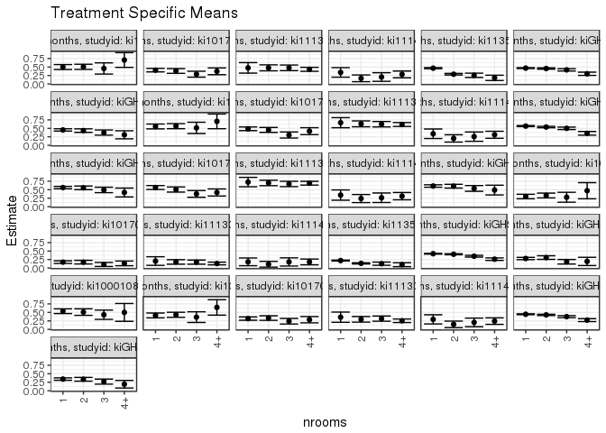

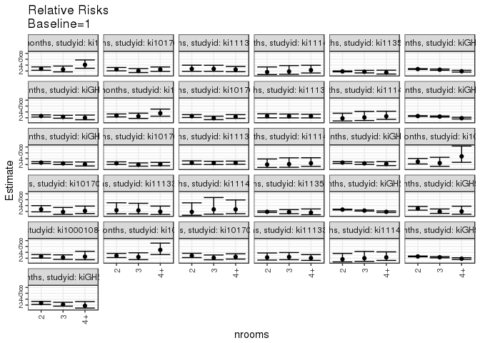

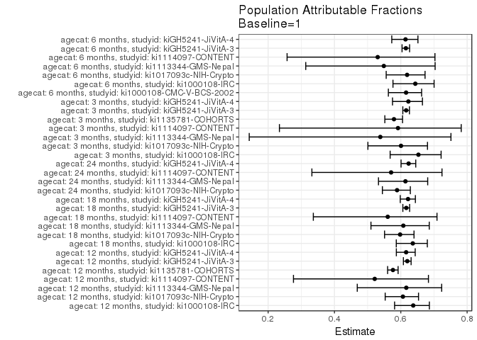

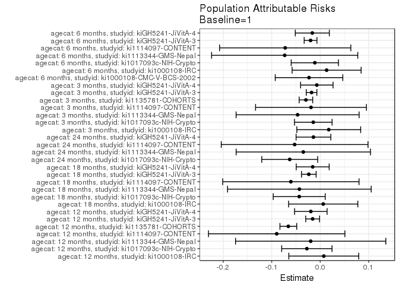

## Data Summary

| agecat | studyid | A | n | nA | nAY0 | nAY1 |
| --- | --- | --- | --- | --- | --- | --- |
| 12 months | ki1000108-CMC-V-BCS-2002 | 1 | 372 | 201 | 58 | 143 |
| 12 months | ki1000108-CMC-V-BCS-2002 | 2 | 372 | 106 | 31 | 75 |
| 12 months | ki1000108-CMC-V-BCS-2002 | 3 | 372 | 51 | 19 | 32 |
| 12 months | ki1000108-CMC-V-BCS-2002 | 4+ | 372 | 14 | 4 | 10 |
| 12 months | ki1000108-IRC | 1 | 408 | 186 | 93 | 93 |
| 12 months | ki1000108-IRC | 2 | 408 | 170 | 84 | 86 |
| 12 months | ki1000108-IRC | 3 | 408 | 35 | 19 | 16 |
| 12 months | ki1000108-IRC | 4+ | 408 | 17 | 5 | 12 |
| 12 months | ki1017093c-NIH-Crypto | 1 | 729 | 346 | 205 | 141 |
| 12 months | ki1017093c-NIH-Crypto | 2 | 729 | 188 | 116 | 72 |
| 12 months | ki1017093c-NIH-Crypto | 3 | 729 | 104 | 74 | 30 |
| 12 months | ki1017093c-NIH-Crypto | 4+ | 729 | 91 | 57 | 34 |
| 12 months | ki1113344-GMS-Nepal | 1 | 582 | 40 | 21 | 19 |
| 12 months | ki1113344-GMS-Nepal | 2 | 582 | 124 | 65 | 59 |
| 12 months | ki1113344-GMS-Nepal | 3 | 582 | 143 | 75 | 68 |
| 12 months | ki1113344-GMS-Nepal | 4+ | 582 | 275 | 156 | 119 |
| 12 months | ki1114097-CONTENT | 1 | 215 | 44 | 29 | 15 |
| 12 months | ki1114097-CONTENT | 2 | 215 | 54 | 45 | 9 |
| 12 months | ki1114097-CONTENT | 3 | 215 | 39 | 31 | 8 |
| 12 months | ki1114097-CONTENT | 4+ | 215 | 78 | 56 | 22 |
| 12 months | ki1135781-COHORTS | 1 | 5022 | 3257 | 1740 | 1517 |
| 12 months | ki1135781-COHORTS | 2 | 5022 | 1487 | 1059 | 428 |
| 12 months | ki1135781-COHORTS | 3 | 5022 | 184 | 137 | 47 |
| 12 months | ki1135781-COHORTS | 4+ | 5022 | 94 | 77 | 17 |
| 12 months | kiGH5241-JiVitA-3 | 1 | 8369 | 4705 | 2506 | 2199 |
| 12 months | kiGH5241-JiVitA-3 | 2 | 8369 | 2453 | 1334 | 1119 |
| 12 months | kiGH5241-JiVitA-3 | 3 | 8369 | 855 | 499 | 356 |
| 12 months | kiGH5241-JiVitA-3 | 4+ | 8369 | 356 | 249 | 107 |
| 12 months | kiGH5241-JiVitA-4 | 1 | 1419 | 849 | 464 | 385 |
| 12 months | kiGH5241-JiVitA-4 | 2 | 1419 | 355 | 201 | 154 |

[output cut: 130 more lines]

## Results Table

### Parameter: TSM

| agecat | studyid | intervention_level | baseline_level | estimate | ci_lower | ci_upper |
| --- | --- | --- | --- | --- | --- | --- |
| 12 months | ki1000108-IRC | 1 | NA | 0.5000000 | 0.4280560 | 0.5719440 |
| 12 months | ki1000108-IRC | 2 | NA | 0.5058824 | 0.4306341 | 0.5811306 |
| 12 months | ki1000108-IRC | 3 | NA | 0.4571429 | 0.2919027 | 0.6223831 |
| 12 months | ki1000108-IRC | 4+ | NA | 0.7058824 | 0.4890205 | 0.9227442 |
| 12 months | ki1017093c-NIH-Crypto | 1 | NA | 0.4075145 | 0.3557039 | 0.4593250 |
| 12 months | ki1017093c-NIH-Crypto | 2 | NA | 0.3829787 | 0.3134435 | 0.4525139 |
| 12 months | ki1017093c-NIH-Crypto | 3 | NA | 0.2884615 | 0.2013305 | 0.3755925 |
| 12 months | ki1017093c-NIH-Crypto | 4+ | NA | 0.3736264 | 0.2741635 | 0.4730892 |
| 12 months | ki1113344-GMS-Nepal | 1 | NA | 0.4750000 | 0.3201119 | 0.6298881 |
| 12 months | ki1113344-GMS-Nepal | 2 | NA | 0.4758065 | 0.3878289 | 0.5637840 |
| 12 months | ki1113344-GMS-Nepal | 3 | NA | 0.4755245 | 0.3936021 | 0.5574469 |
| 12 months | ki1113344-GMS-Nepal | 4+ | NA | 0.4327273 | 0.3741191 | 0.4913355 |
| 12 months | ki1114097-CONTENT | 1 | NA | 0.3409091 | 0.2005224 | 0.4812958 |
| 12 months | ki1114097-CONTENT | 2 | NA | 0.1666667 | 0.0670350 | 0.2662983 |
| 12 months | ki1114097-CONTENT | 3 | NA | 0.2051282 | 0.0781032 | 0.3321533 |
| 12 months | ki1114097-CONTENT | 4+ | NA | 0.2820513 | 0.1819536 | 0.3821489 |
| 12 months | ki1135781-COHORTS | 1 | NA | 0.4657660 | 0.4486331 | 0.4828990 |
| 12 months | ki1135781-COHORTS | 2 | NA | 0.2878278 | 0.2648137 | 0.3108420 |
| 12 months | ki1135781-COHORTS | 3 | NA | 0.2554348 | 0.1924154 | 0.3184541 |
| 12 months | ki1135781-COHORTS | 4+ | NA | 0.1808511 | 0.1030350 | 0.2586671 |
| 12 months | kiGH5241-JiVitA-3 | 1 | NA | 0.4673751 | 0.4531178 | 0.4816324 |
| 12 months | kiGH5241-JiVitA-3 | 2 | NA | 0.4561761 | 0.4364646 | 0.4758877 |
| 12 months | kiGH5241-JiVitA-3 | 3 | NA | 0.4163743 | 0.3833297 | 0.4494188 |
| 12 months | kiGH5241-JiVitA-3 | 4+ | NA | 0.3005618 | 0.2529307 | 0.3481929 |
| 12 months | kiGH5241-JiVitA-4 | 1 | NA | 0.4534747 | 0.4199759 | 0.4869735 |
| 12 months | kiGH5241-JiVitA-4 | 2 | NA | 0.4338028 | 0.3822305 | 0.4853752 |
| 12 months | kiGH5241-JiVitA-4 | 3 | NA | 0.3757962 | 0.3000099 | 0.4515825 |
| 12 months | kiGH5241-JiVitA-4 | 4+ | NA | 0.3103448 | 0.1912411 | 0.4294486 |
| 18 months | ki1000108-IRC | 1 | NA | 0.5561497 | 0.4848525 | 0.6274470 |
| 18 months | ki1000108-IRC | 2 | NA | 0.5647059 | 0.4900855 | 0.6393263 |

[output cut: 94 more lines]

### Parameter: E(Y)

| agecat | studyid | intervention_level | baseline_level | estimate | ci_lower | ci_upper |
| --- | --- | --- | --- | --- | --- | --- |
| 12 months | ki1000108-IRC | NA | NA | 0.5073529 | 0.5031360 | 0.5115699 |
| 12 months | ki1017093c-NIH-Crypto | NA | NA | 0.3799726 | 0.3771016 | 0.3828436 |
| 12 months | ki1113344-GMS-Nepal | NA | NA | 0.4553265 | 0.4535872 | 0.4570657 |
| 12 months | ki1114097-CONTENT | NA | NA | 0.2511628 | 0.2425088 | 0.2598168 |
| 12 months | ki1135781-COHORTS | NA | NA | 0.4000398 | 0.3975358 | 0.4025438 |
| 12 months | kiGH5241-JiVitA-3 | NA | NA | 0.4517864 | 0.4510309 | 0.4525418 |
| 12 months | kiGH5241-JiVitA-4 | NA | NA | 0.4341085 | 0.4322855 | 0.4359315 |
| 18 months | ki1000108-IRC | NA | NA | 0.5623472 | 0.5591674 | 0.5655270 |
| 18 months | ki1017093c-NIH-Crypto | NA | NA | 0.4433566 | 0.4388523 | 0.4478610 |
| 18 months | ki1113344-GMS-Nepal | NA | NA | 0.6236934 | 0.6225644 | 0.6248224 |
| 18 months | ki1114097-CONTENT | NA | NA | 0.2803738 | 0.2734031 | 0.2873445 |
| 18 months | kiGH5241-JiVitA-3 | NA | NA | 0.5436177 | 0.5426063 | 0.5446292 |
| 18 months | kiGH5241-JiVitA-4 | NA | NA | 0.5477753 | 0.5459752 | 0.5495755 |
| 24 months | ki1017093c-NIH-Crypto | NA | NA | 0.5015773 | 0.4960526 | 0.5071020 |
| 24 months | ki1113344-GMS-Nepal | NA | NA | 0.6901408 | 0.6889390 | 0.6913426 |
| 24 months | ki1114097-CONTENT | NA | NA | 0.2893401 | 0.2840296 | 0.2946506 |
| 24 months | kiGH5241-JiVitA-4 | NA | NA | 0.5949791 | 0.5932319 | 0.5967262 |
| 3 months | ki1000108-IRC | NA | NA | 0.3170732 | 0.3135557 | 0.3205906 |
| 3 months | ki1017093c-NIH-Crypto | NA | NA | 0.1596306 | 0.1578774 | 0.1613838 |
| 3 months | ki1113344-GMS-Nepal | NA | NA | 0.1585160 | 0.1565521 | 0.1604800 |
| 3 months | ki1114097-CONTENT | NA | NA | 0.1627907 | 0.1587789 | 0.1668025 |
| 3 months | ki1135781-COHORTS | NA | NA | 0.1906412 | 0.1895266 | 0.1917559 |
| 3 months | kiGH5241-JiVitA-3 | NA | NA | 0.4035955 | 0.4029820 | 0.4042090 |
| 3 months | kiGH5241-JiVitA-4 | NA | NA | 0.2735931 | 0.2714078 | 0.2757783 |
| 6 months | ki1000108-CMC-V-BCS-2002 | NA | NA | 0.5122616 | 0.5087058 | 0.5158174 |
| 6 months | ki1000108-IRC | NA | NA | 0.4240196 | 0.4191492 | 0.4288900 |
| 6 months | ki1017093c-NIH-Crypto | NA | NA | 0.3070652 | 0.3048713 | 0.3092591 |
| 6 months | ki1113344-GMS-Nepal | NA | NA | 0.2857143 | 0.2829560 | 0.2884725 |
| 6 months | ki1114097-CONTENT | NA | NA | 0.2232558 | 0.2163027 | 0.2302089 |
| 6 months | kiGH5241-JiVitA-3 | NA | NA | 0.4256672 | 0.4248933 | 0.4264411 |
| 6 months | kiGH5241-JiVitA-4 | NA | NA | 0.3273961 | 0.3253101 | 0.3294821 |

### Parameter: RR

| agecat | studyid | intervention_level | baseline_level | estimate | ci_lower | ci_upper |
| --- | --- | --- | --- | --- | --- | --- |
| 12 months | ki1000108-IRC | 2 | 1 | 2.750450 | 2.2362768 | 3.382845 |
| 12 months | ki1000108-IRC | 3 | 1 | 2.494992 | 1.6908589 | 3.681554 |
| 12 months | ki1000108-IRC | 4+ | 1 | 4.103190 | 2.9227290 | 5.760427 |
| 12 months | ki1017093c-NIH-Crypto | 2 | 1 | 2.559448 | 2.0506151 | 3.194542 |
| 12 months | ki1017093c-NIH-Crypto | 3 | 1 | 2.029635 | 1.4624826 | 2.816730 |
| 12 months | ki1017093c-NIH-Crypto | 4+ | 1 | 2.501379 | 1.8623347 | 3.359705 |
| 12 months | ki1113344-GMS-Nepal | 2 | 1 | 2.722901 | 1.8716902 | 3.961227 |
| 12 months | ki1113344-GMS-Nepal | 3 | 1 | 2.721285 | 1.8819559 | 3.934944 |
| 12 months | ki1113344-GMS-Nepal | 4+ | 1 | 2.486820 | 1.7470271 | 3.539884 |
| 12 months | ki1114097-CONTENT | 2 | 1 | 1.630504 | 0.7889814 | 3.369587 |
| 12 months | ki1114097-CONTENT | 3 | 1 | 1.825236 | 0.8676543 | 3.839648 |
| 12 months | ki1114097-CONTENT | 4+ | 1 | 2.287250 | 1.3280681 | 3.939192 |
| 12 months | ki1135781-COHORTS | 2 | 1 | 1.855152 | 1.6988526 | 2.025831 |
| 12 months | ki1135781-COHORTS | 3 | 1 | 1.730514 | 1.3484793 | 2.220783 |
| 12 months | ki1135781-COHORTS | 4+ | 1 | 1.474453 | 0.9573758 | 2.270804 |
| 12 months | kiGH5241-JiVitA-3 | 2 | 1 | 2.653922 | 2.5171951 | 2.798075 |
| 12 months | kiGH5241-JiVitA-3 | 3 | 1 | 2.437269 | 2.2386088 | 2.653558 |
| 12 months | kiGH5241-JiVitA-3 | 4+ | 1 | 1.902340 | 1.6188270 | 2.235506 |
| 12 months | kiGH5241-JiVitA-4 | 2 | 1 | 2.602883 | 2.2629150 | 2.993926 |
| 12 months | kiGH5241-JiVitA-4 | 3 | 1 | 2.290348 | 1.8476809 | 2.839069 |
| 12 months | kiGH5241-JiVitA-4 | 4+ | 1 | 1.982524 | 1.3411765 | 2.930563 |
| 18 months | ki1000108-IRC | 2 | 1 | 2.760425 | 2.2962480 | 3.318433 |
| 18 months | ki1000108-IRC | 3 | 1 | 2.521176 | 1.7821390 | 3.566684 |
| 18 months | ki1000108-IRC | 4+ | 1 | 3.558114 | 2.5506189 | 4.963571 |
| 18 months | ki1017093c-NIH-Crypto | 2 | 1 | 2.542190 | 2.0971079 | 3.081733 |
| 18 months | ki1017093c-NIH-Crypto | 3 | 1 | 1.867353 | 1.3645217 | 2.555479 |
| 18 months | ki1017093c-NIH-Crypto | 4+ | 1 | 2.358630 | 1.8069146 | 3.078804 |
| 18 months | ki1113344-GMS-Nepal | 2 | 1 | 2.585710 | 1.9925626 | 3.355425 |
| 18 months | ki1113344-GMS-Nepal | 3 | 1 | 2.543565 | 1.9685920 | 3.286471 |
| 18 months | ki1113344-GMS-Nepal | 4+ | 1 | 2.511690 | 1.9731783 | 3.197170 |

[output cut: 63 more lines]

### Parameter: PAR

| agecat | studyid | intervention_level | baseline_level | estimate | ci_lower | ci_upper |
| --- | --- | --- | --- | --- | --- | --- |
| 12 months | ki1000108-IRC | 1 | NA | 0.0073529 | -0.0647145 | 0.0794204 |
| 12 months | ki1017093c-NIH-Crypto | 1 | NA | -0.0275419 | -0.0794320 | 0.0243482 |
| 12 months | ki1113344-GMS-Nepal | 1 | NA | -0.0196735 | -0.1745714 | 0.1352243 |
| 12 months | ki1114097-CONTENT | 1 | NA | -0.0897463 | -0.2303995 | 0.0509069 |
| 12 months | ki1135781-COHORTS | 1 | NA | -0.0657262 | -0.0830412 | -0.0484113 |
| 12 months | kiGH5241-JiVitA-3 | 1 | NA | -0.0155888 | -0.0298661 | -0.0013115 |
| 12 months | kiGH5241-JiVitA-4 | 1 | NA | -0.0193661 | -0.0529145 | 0.0141822 |
| 18 months | ki1000108-IRC | 1 | NA | 0.0061975 | -0.0651707 | 0.0775656 |
| 18 months | ki1017093c-NIH-Crypto | 1 | NA | -0.0432902 | -0.0968812 | 0.0103007 |
| 18 months | ki1113344-GMS-Nepal | 1 | NA | -0.0429733 | -0.1910548 | 0.1051082 |
| 18 months | ki1114097-CONTENT | 1 | NA | -0.0605353 | -0.2010965 | 0.0800260 |
| 18 months | kiGH5241-JiVitA-3 | 1 | NA | -0.0235141 | -0.0386127 | -0.0084155 |
| 18 months | kiGH5241-JiVitA-4 | 1 | NA | -0.0154850 | -0.0494512 | 0.0184812 |
| 24 months | ki1017093c-NIH-Crypto | 1 | NA | -0.0628826 | -0.1205569 | -0.0052084 |
| 24 months | ki1113344-GMS-Nepal | 1 | NA | -0.0348592 | -0.1733600 | 0.1036417 |
| 24 months | ki1114097-CONTENT | 1 | NA | -0.0527652 | -0.2040819 | 0.0985516 |
| 24 months | kiGH5241-JiVitA-4 | 1 | NA | -0.0139595 | -0.0497609 | 0.0218420 |
| 3 months | ki1000108-IRC | 1 | NA | 0.0176079 | -0.0482134 | 0.0834293 |
| 3 months | ki1017093c-NIH-Crypto | 1 | NA | -0.0142824 | -0.0530737 | 0.0245088 |
| 3 months | ki1113344-GMS-Nepal | 1 | NA | -0.0466122 | -0.1734637 | 0.0802393 |
| 3 months | ki1114097-CONTENT | 1 | NA | -0.0190275 | -0.1333272 | 0.0952723 |
| 3 months | ki1135781-COHORTS | 1 | NA | -0.0294587 | -0.0434248 | -0.0154925 |
| 3 months | kiGH5241-JiVitA-3 | 1 | NA | -0.0178541 | -0.0288139 | -0.0068943 |
| 3 months | kiGH5241-JiVitA-4 | 1 | NA | -0.0069825 | -0.0404704 | 0.0265054 |
| 6 months | ki1000108-CMC-V-BCS-2002 | 1 | NA | -0.0230920 | -0.0927476 | 0.0465637 |
| 6 months | ki1000108-IRC | 1 | NA | 0.0132088 | -0.0579393 | 0.0843569 |
| 6 months | ki1017093c-NIH-Crypto | 1 | NA | -0.0111166 | -0.0598565 | 0.0376233 |
| 6 months | ki1113344-GMS-Nepal | 1 | NA | -0.0732601 | -0.2239698 | 0.0774496 |
| 6 months | ki1114097-CONTENT | 1 | NA | -0.0721987 | -0.2075020 | 0.0631045 |
| 6 months | kiGH5241-JiVitA-3 | 1 | NA | -0.0198900 | -0.0330585 | -0.0067214 |
| 6 months | kiGH5241-JiVitA-4 | 1 | NA | -0.0163097 | -0.0513957 | 0.0187763 |

### Parameter: PAF

| agecat | studyid | intervention_level | baseline_level | estimate | ci_lower | ci_upper |
| --- | --- | --- | --- | --- | --- | --- |
| 12 months | ki1000108-IRC | 1 | NA | 0.6374910 | 0.5812906 | 0.6861480 |
| 12 months | ki1017093c-NIH-Crypto | 1 | NA | 0.6063980 | 0.5529356 | 0.6534670 |
| 12 months | ki1113344-GMS-Nepal | 1 | NA | 0.6165638 | 0.4687271 | 0.7232621 |
| 12 months | ki1114097-CONTENT | 1 | NA | 0.5213302 | 0.2763911 | 0.6833582 |
| 12 months | ki1135781-COHORTS | 1 | NA | 0.5763662 | 0.5602604 | 0.5918820 |
| 12 months | kiGH5241-JiVitA-3 | 1 | NA | 0.6196434 | 0.6078439 | 0.6310879 |
| 12 months | kiGH5241-JiVitA-4 | 1 | NA | 0.6160696 | 0.5865850 | 0.6434513 |
| 18 months | ki1000108-IRC | 1 | NA | 0.6361973 | 0.5863855 | 0.6800102 |
| 18 months | ki1017093c-NIH-Crypto | 1 | NA | 0.5978957 | 0.5510489 | 0.6398542 |
| 18 months | ki1113344-GMS-Nepal | 1 | NA | 0.6076261 | 0.5100328 | 0.6857804 |
| 18 months | ki1114097-CONTENT | 1 | NA | 0.5606373 | 0.3362665 | 0.7091610 |
| 18 months | kiGH5241-JiVitA-3 | 1 | NA | 0.6165471 | 0.6061994 | 0.6266230 |
| 18 months | kiGH5241-JiVitA-4 | 1 | NA | 0.6218666 | 0.5983606 | 0.6439970 |
| 24 months | ki1017093c-NIH-Crypto | 1 | NA | 0.5887676 | 0.5444710 | 0.6287567 |
| 24 months | ki1113344-GMS-Nepal | 1 | NA | 0.6140002 | 0.5327459 | 0.6811246 |
| 24 months | ki1114097-CONTENT | 1 | NA | 0.5707704 | 0.3319180 | 0.7242284 |
| 24 months | kiGH5241-JiVitA-4 | 1 | NA | 0.6235898 | 0.6007946 | 0.6450833 |
| 3 months | ki1000108-IRC | 1 | NA | 0.6531275 | 0.5678729 | 0.7215621 |
| 3 months | ki1017093c-NIH-Crypto | 1 | NA | 0.6006336 | 0.5008176 | 0.6804905 |
| 3 months | ki1113344-GMS-Nepal | 1 | NA | 0.5382657 | 0.1429976 | 0.7512275 |
| 3 months | ki1114097-CONTENT | 1 | NA | 0.5915349 | 0.2340239 | 0.7821815 |
| 3 months | ki1135781-COHORTS | 1 | NA | 0.5794356 | 0.5518543 | 0.6053195 |
| 3 months | kiGH5241-JiVitA-3 | 1 | NA | 0.6162011 | 0.6060880 | 0.6260545 |
| 3 months | kiGH5241-JiVitA-4 | 1 | NA | 0.6228506 | 0.5750341 | 0.6652868 |
| 6 months | ki1000108-CMC-V-BCS-2002 | 1 | NA | 0.6159052 | 0.5625264 | 0.6627710 |
| 6 months | ki1000108-IRC | 1 | NA | 0.6437608 | 0.5764096 | 0.7004032 |
| 6 months | ki1017093c-NIH-Crypto | 1 | NA | 0.6190405 | 0.5559722 | 0.6731507 |
| 6 months | ki1113344-GMS-Nepal | 1 | NA | 0.5488333 | 0.3134275 | 0.7035253 |
| 6 months | ki1114097-CONTENT | 1 | NA | 0.5302878 | 0.2571280 | 0.7030046 |
| 6 months | kiGH5241-JiVitA-3 | 1 | NA | 0.6153261 | 0.6037854 | 0.6265307 |
| 6 months | kiGH5241-JiVitA-4 | 1 | NA | 0.6142429 | 0.5727763 | 0.6516848 |